# Lecture 1.2 - Characteristics of distributions activity

DKU Stats 101 Spring 2026 Session 4

Author

Professor MacDonald

Published

October 28, 2026

# Lecture 1.2 in-class activity - exploring distributions

## How to Make High-Quality Histograms

> Adapted from the [STHDA guide](http://www.sthda.com/english/wiki/ggplot2-histogram-plot-quick-start-guide-r-software-and-data-visualization). Additional resources: [histogram documentation](https://ggplot2.tidyverse.org/reference/geom_histogram.html) and [density-plot documentation](https://ggplot2.tidyverse.org/reference/geom_density.html).

How evenly is internet access distributed around the world? What does a “typical” country’s life expectancy or economic output look like?

We will use **`AllCountries` from the `Lock5Data` R package**, a teaching dataset containing **217 countries and economies**. The fourth-edition version contains mostly **2023 data, or the most recently available year for each measure**, compiled from sources accessed in January 2025. It is a fixed teaching snapshot, not a live feed or a record of conditions today. The documentation does not identify a year for every individual value, so we should not describe all observations as being from exactly the same year.[^1]

**Our unit of observation is a country or economy, not an individual person.** Some entries are territories rather than sovereign states. For brevity, the questions below refer to these observations as “countries.” Each country counts once in our graphs and averages, regardless of population size.

### Part 1: Setup

Install the packages **once**, using the RStudio Console. Reinstall `Lock5Data` if you already have an older version: earlier editions contain older observations and different columns. This activity uses **version 4.0.1 or later** of `Lock5Data`.[^2]

```r
install.packages(c("tidyverse", "Lock5Data"),
                 repos = "https://cloud.r-project.org")
```

The installation needs an internet connection. After installation, the dataset is stored in the package: there is no account, API key, separate data download, or live data connection to manage.

Open **File > New File > R Script** in RStudio. Save your script and add the following code at the top. Run the examples in order; later examples use objects created earlier.

```r
library(tidyverse)
library(Lock5Data)

data("AllCountries", package = "Lock5Data")

# Select the columns used in this activity and give them shorter names.
country_data <- as_tibble(AllCountries) %>%
  transmute(
    country = Country,
    internet = Internet,
    life_expectancy = LifeExpectancy,
    gdp_per_capita = GDP,
    population_millions = Population,
    hdi_group = factor(HDIGroup,
                       levels = c("Low", "Medium", "High", "Very High"))
  )
```

The `%>%` symbol passes a dataset to the next step. `transmute()` selects or creates columns. You can use this preparation code as given; we will study data manipulation in more detail later.

Here are the variables we will use. Their definitions follow the package documentation.[^3]

| Variable in our script | Meaning |
| --- | --- |
| `country` | Country or economy name. |
| `internet` | Percentage of the population with internet access, as labelled in the teaching dataset. Values are on a 0–100 scale. |
| `life_expectancy` | Life expectancy, in years. |
| `gdp_per_capita` | Gross domestic product per person, in U.S. dollars. This measures economic output per person, not an individual’s salary. |
| `population_millions` | Population, in millions; included to help us think about weighting. |
| `hdi_group` | Human Development Index category: Low, Medium, High, or Very High. |

Type `View(country_data)` to inspect the data, or `?AllCountries` to read its documentation. R is case-sensitive: `AllCountries` and `allcountries` are not the same name.

**Missing data are not zero.** R uses `NA` for missing values. Check how much information is available before drawing conclusions:

```r
country_data %>%
  summarize(
    total_rows = n(),
    internet_missing = sum(is.na(internet)),
    life_expectancy_missing = sum(is.na(life_expectancy)),
    gdp_missing = sum(is.na(gdp_per_capita)),
    hdi_group_missing = sum(is.na(hdi_group))
  )
```

```
# A tibble: 1 × 5
  total_rows internet_missing life_expectancy_missing gdp_missing
       <int>            <int>                   <int>       <int>
1        217               24                       7           6
# ℹ 1 more variable: hdi_group_missing <int>
```

```r
# Keep all countries with an observed internet value for Parts 2 and 3.
internet_data <- country_data %>%
  filter(!is.na(internet))

nrow(internet_data)
```

```
[1] 193
```

`is.na()` identifies missing values; `!` means “not.” We remove rows only when the variable needed for that analysis is missing. We do **not** require complete information on all 29 original variables. No missing values are replaced or imputed.

### Part 2: Basic Histograms

`ggplot()` is the basic graphing function you will use repeatedly. Let’s examine **internet access across countries**:

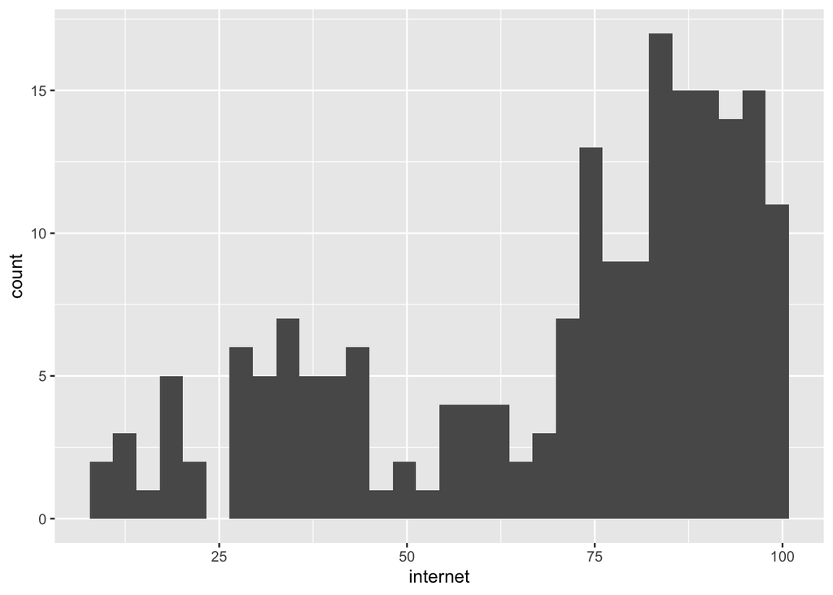

```r
ggplot(internet_data, aes(x = internet)) +
  geom_histogram()
```

The graph has three main components:

1. The dataset being used (`internet_data`).
2. The variable displayed, specified inside `aes()` (`internet`).
3. The kind of graph, added with a `+` (`geom_histogram()`).

The default settings are not always ideal. In particular, the **binwidth** changes how much detail the histogram shows. Let’s make each bin **5 percentage points** wide:

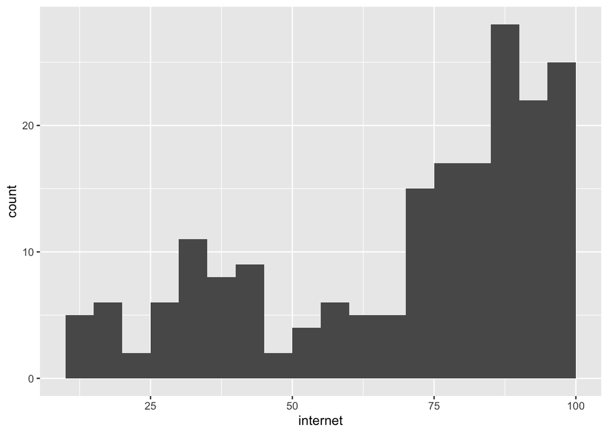

```r
ggplot(internet_data, aes(x = internet)) +
  geom_histogram(binwidth = 5, boundary = 0)
```

`boundary = 0` aligns the bin boundaries with multiples of the binwidth. A change from 60% to 65% is **5 percentage points**, not a 5% relative increase.

> Copy the code into your R script. Highlight it and select **Run**, or press **Ctrl + Enter** on Windows/Linux or **Command + Enter** on macOS. Add the later examples to the same script.

> Try binwidths of `2`, `5`, `10`, and `20` percentage points. Which gives the clearest picture of the distribution?
1. Describe the **shape, center, and spread** of internet access across countries. Are there possible outliers?
2. How does changing the binwidth affect your answers? What information disappears with very wide bins?
3. Does a bar count countries or people? Does a value of 80% mean that every person in that country has the same access?

We can add labels:

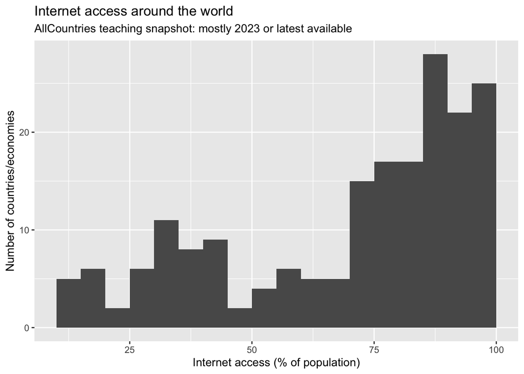

```r
ggplot(internet_data, aes(x = internet)) +
  geom_histogram(binwidth = 5, boundary = 0) +
  labs(
    x = "Internet access (% of population)",
    y = "Number of countries/economies",
    title = "Internet access around the world",
    subtitle = "AllCountries teaching snapshot: mostly 2023 or latest available"
  )
```

Each `+` adds another layer to the graph.

### Part 3: Adding layers to the histogram

Let’s add a line showing the **mean of the country percentages**. First, save the plot as an object called `p`:

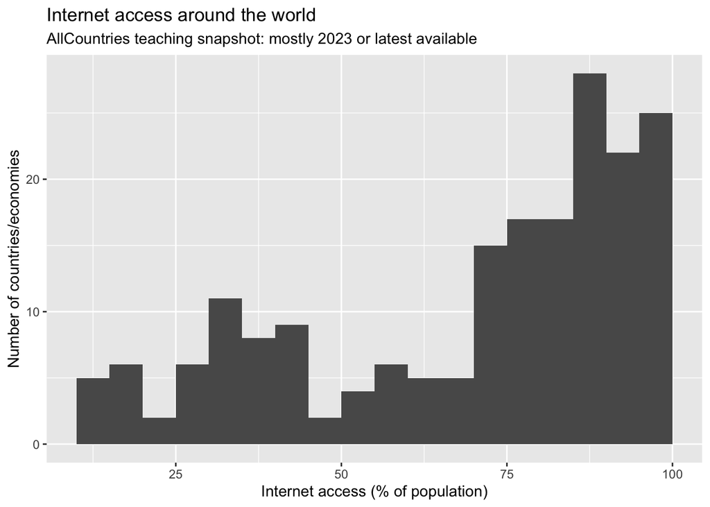

```r
p <- ggplot(internet_data, aes(x = internet)) +
  geom_histogram(binwidth = 5, boundary = 0) +
  labs(
    x = "Internet access (% of population)",
    y = "Number of countries/economies",
    title = "Internet access around the world",
    subtitle = "AllCountries teaching snapshot: mostly 2023 or latest available"
  )

p
```

To add a vertical dashed line at the mean:

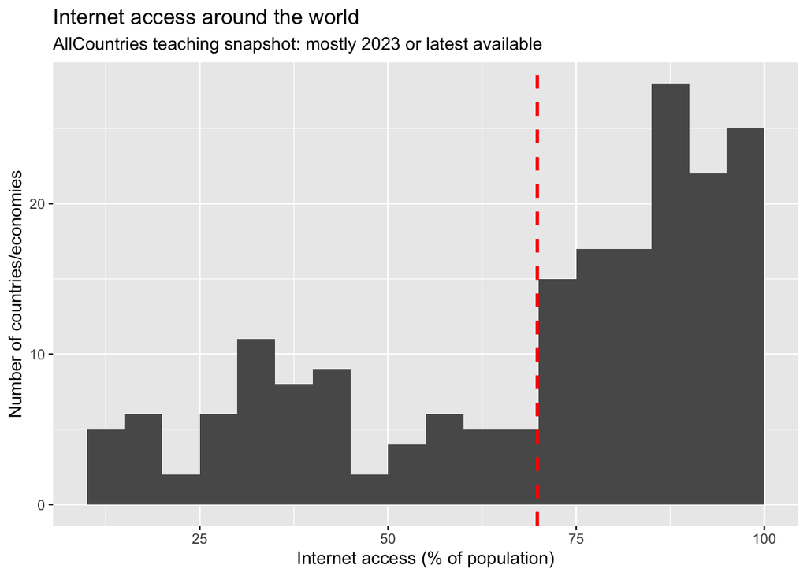

```r
p + geom_vline(
  xintercept = mean(internet_data$internet),
  color = "red", linetype = "dashed", linewidth = 1
)
```

The `$` selects a column from a dataset. This mean gives equal weight to each country with an observed value. It is **not** the percentage of the world’s people with internet access.

Now change the histogram’s vertical axis from **counts** to **density**:

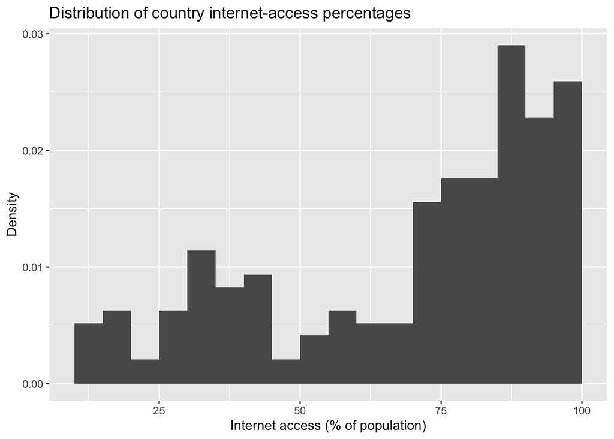

```r
p <- ggplot(internet_data, aes(x = internet)) +
  geom_histogram(aes(y = after_stat(density)),
                 binwidth = 5, boundary = 0) +
  labs(
    x = "Internet access (% of population)",
    y = "Density",
    title = "Distribution of country internet-access percentages"
  )

p
```

This overwrites the previous version of `p`. The **total area** of the density histogram’s bars is 1. A bar’s area is its height multiplied by its width; its height alone is not the proportion of countries in that interval.

Overlay a smooth density curve:

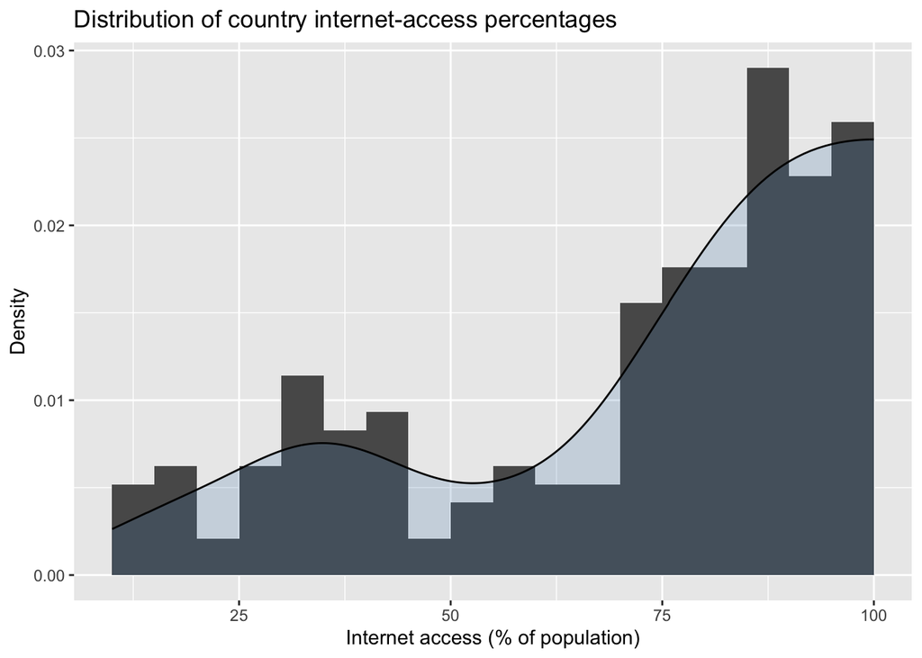

```r
p + geom_density(bounds = c(0, 100), alpha = 0.2, fill = "steelblue")
```

`bounds = c(0, 100)` tells the smoother that percentages cannot be below 0 or above 100. The curve is a summary of the distribution, not additional data.

> How does the curve help you see the overall shape? What details might it smooth away? What does the 100% upper bound imply about the possible shape?

### Part 4: Comparing distributions across categories

Does internet access differ across **Human Development Index (HDI) groups**? HDI summarizes health, education, and income. Its categories are useful for description but do not capture every aspect of a society.[^4]

We used `factor()` in the setup to tell R to treat `hdi_group` as categorical and to display its levels in a meaningful order. For this comparison, we also need an observed group label:

```r
internet_by_hdi <- internet_data %>%
  filter(!is.na(hdi_group))

# Check group sizes and how many otherwise usable rows lack a group label.
internet_by_hdi %>% count(hdi_group)
```

```
# A tibble: 4 × 2
  hdi_group     n
  <fct>     <int>
1 Low          33
2 Medium       41
3 High         47
4 Very High    69
```

```r
nrow(internet_data) - nrow(internet_by_hdi)
```

```
[1] 3
```

We can color the outlines of histogram bars by group:

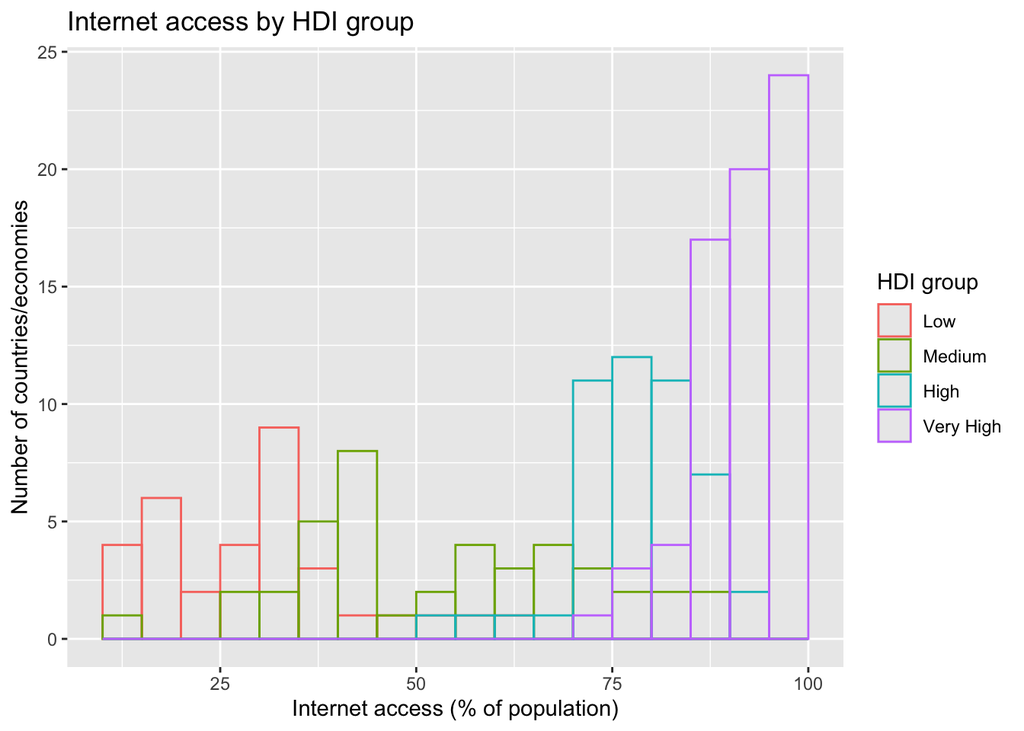

```r
ggplot(internet_by_hdi, aes(x = internet, color = hdi_group)) +
  geom_histogram(binwidth = 5, boundary = 0,
                 fill = NA, position = "identity") +
  labs(
    x = "Internet access (% of population)",
    y = "Number of countries/economies",
    title = "Internet access by HDI group",
    color = "HDI group"
  )
```

`position = "identity"` overlays the groups instead of stacking them. Because overlapping bars can be hard to interpret, a clearer approach is to create a **separate histogram for each group** with `facet_wrap()`:

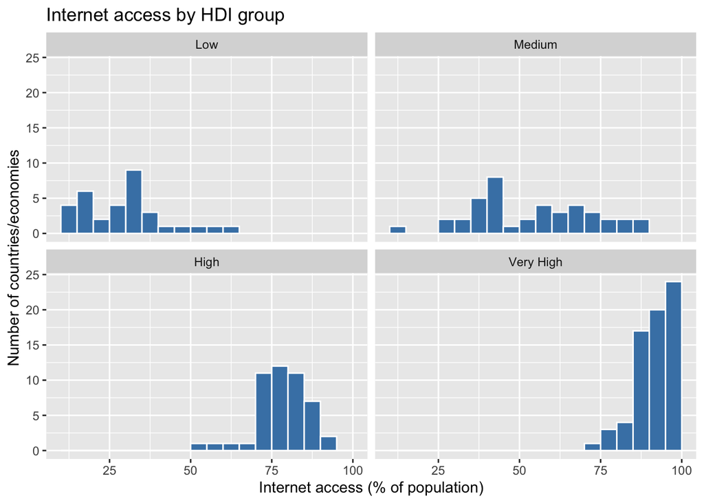

```r
ggplot(internet_by_hdi, aes(x = internet)) +
  geom_histogram(binwidth = 5, boundary = 0,
                 fill = "steelblue", color = "white") +
  facet_wrap(~ hdi_group, ncol = 2) +
  labs(
    x = "Internet access (% of population)",
    y = "Number of countries/economies",
    title = "Internet access by HDI group"
  )
```

The panels use the same axes and bin boundaries. Group sizes differ, so a taller bar does not necessarily indicate a larger **proportion** of that group. To compare relative shapes, try adding `aes(y = after_stat(density))` inside `geom_histogram()` and change the y-axis label to `"Density"`.

Next, calculate the mean internet-access percentage in each group. We will learn these data-manipulation commands in more detail later.

```r
hdi_means <- internet_by_hdi %>%
  group_by(hdi_group) %>%
  summarize(
    n_countries = n(),
    grp_mean = mean(internet),
    .groups = "drop"
  )

hdi_means
```

```
# A tibble: 4 × 3
  hdi_group n_countries grp_mean
  <fct>           <int>    <dbl>
1 Low                33     29.8
2 Medium             41     54.2
3 High               47     78.2
4 Very High          69     91.6
```

Add a separate dashed mean line to each group histogram:

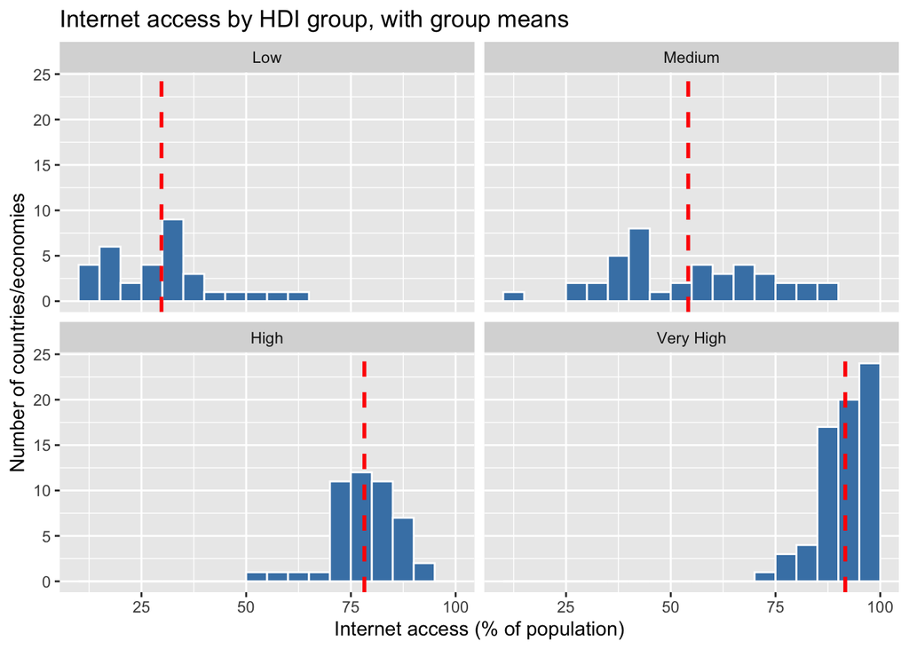

```r
ggplot(internet_by_hdi, aes(x = internet)) +
  geom_histogram(binwidth = 5, boundary = 0,
                 fill = "steelblue", color = "white") +
  facet_wrap(~ hdi_group, ncol = 2) +
  geom_vline(
    data = hdi_means,
    aes(xintercept = grp_mean),
    color = "red", linetype = "dashed", linewidth = 1
  ) +
  labs(
    x = "Internet access (% of population)",
    y = "Number of countries/economies",
    title = "Internet access by HDI group, with group means"
  )
```

1. Which group has the highest mean? Does it also contain the country with the highest individual value? Allow for ties.
2. Do the group distributions overlap? How much variation remains within each group?
3. Why can’t these plots establish that a higher HDI **causes** greater internet access, or the reverse?

## Thinking about distributions of variables in this dataset

Two other variables are **`gdp_per_capita`** (economic output per person, in U.S. dollars) and **`life_expectancy`** (years). GDP per capita is not a typical person’s income, and a country-level life expectancy does not tell us how long a particular individual will live.

### Estimating basic characteristics of the distributions

**Before making the next graphs or calculating summary statistics**, predict the shape, center, and spread for `gdp_per_capita` and `life_expectancy`:

- **Shape:** Symmetric, skewed left, skewed right, or possibly multimodal?
- **Center:** What would you guess is a typical country value?
- **Spread:** How different might countries be from one another? Include units.

Think about why these two social indicators might have different distribution shapes.

### Further refining your mental model of distributions

Calculate measures for **both** variables. Compare the mean and median for clues about skew, but use a histogram to check the shape. Examine the minimum, maximum, range, IQR, and standard deviation to describe spread.

`na.rm = TRUE` excludes missing values from each calculation. The observed and missing counts show how many countries contribute to each summary. The final `pivot_longer()` line simply puts the results into a readable two-column table.

```r
gdp_summary <- country_data %>%
  summarize(
    n_observed = sum(!is.na(gdp_per_capita)),
    n_missing = sum(is.na(gdp_per_capita)),
    mean = mean(gdp_per_capita, na.rm = TRUE),
    median = median(gdp_per_capita, na.rm = TRUE),
    minimum = min(gdp_per_capita, na.rm = TRUE),
    maximum = max(gdp_per_capita, na.rm = TRUE),
    range = max(gdp_per_capita, na.rm = TRUE) -
            min(gdp_per_capita, na.rm = TRUE),
    IQR = IQR(gdp_per_capita, na.rm = TRUE),
    sd = sd(gdp_per_capita, na.rm = TRUE)
  ) %>%
  pivot_longer(everything(), names_to = "statistic", values_to = "value")

gdp_summary
```

```
# A tibble: 9 × 2
  statistic    value
  <chr>        <dbl>
1 n_observed    211
2 n_missing       6
3 mean        21914.
4 median       8233
5 minimum       193
6 maximum    256581
7 range      256388
8 IQR         27510.
9 sd          32184.
```

```r
life_summary <- country_data %>%
  summarize(
    n_observed = sum(!is.na(life_expectancy)),
    n_missing = sum(is.na(life_expectancy)),
    mean = mean(life_expectancy, na.rm = TRUE),
    median = median(life_expectancy, na.rm = TRUE),
    minimum = min(life_expectancy, na.rm = TRUE),
    maximum = max(life_expectancy, na.rm = TRUE),
    range = max(life_expectancy, na.rm = TRUE) -
            min(life_expectancy, na.rm = TRUE),
    IQR = IQR(life_expectancy, na.rm = TRUE),
    sd = sd(life_expectancy, na.rm = TRUE)
  ) %>%
  pivot_longer(everything(), names_to = "statistic", values_to = "value")

life_summary
```

```
# A tibble: 9 × 2
  statistic   value
  <chr>       <dbl>
1 n_observed 210
2 n_missing    7
3 mean        72.5
4 median      73.6
5 minimum     53
6 maximum     85.4
7 range       32.4
8 IQR         11.7
9 sd           7.72
```

To examine repeated values (potential modes), use `count()` and sort by frequency:

```r
gdp_counts <- country_data %>%
  filter(!is.na(gdp_per_capita)) %>%
  count(gdp_per_capita, sort = TRUE)

life_counts <- country_data %>%
  filter(!is.na(life_expectancy)) %>%
  count(life_expectancy, sort = TRUE)

gdp_counts
```

```
# A tibble: 209 × 2
   gdp_per_capita     n
            <int> <int>
 1           1706     2
 2           6678     2
 3            193     1
 4            416     1
 5            477     1
 6            496     1
 7            506     1
 8            597     1
 9            602     1
10            623     1
# ℹ 199 more rows
```

```r
life_counts
```

```
# A tibble: 142 × 2
   life_expectancy     n
             <dbl> <int>
 1            74.4     6
 2            74.6     5
 3            62.9     4
 4            71.3     4
 5            73.4     4
 6            81.6     4
 7            63.7     3
 8            70.5     3
 9            72.2     3
10            75.3     3
# ℹ 132 more rows
```

> For variables with many different numeric values, the most frequently observed **exact** value may not be informative. Recorded values may also be rounded. Use histograms to look for peaks or clusters; do not use R’s `mode()` function to find a statistical mode.

### Checking your work

Create histograms of `gdp_per_capita` and `life_expectancy`. The code below excludes missing observations from each graph separately, matching its summary table:

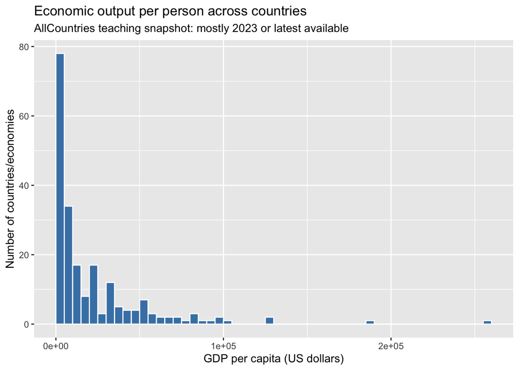

```r
ggplot(filter(country_data, !is.na(gdp_per_capita)),
       aes(x = gdp_per_capita)) +
  geom_histogram(binwidth = 5000, boundary = 0,
                 fill = "steelblue", color = "white") +
  labs(
    x = "GDP per capita (US dollars)", y = "Number of countries/economies",
    title = "Economic output per person across countries",
    subtitle = "AllCountries teaching snapshot: mostly 2023 or latest available"
  )
```

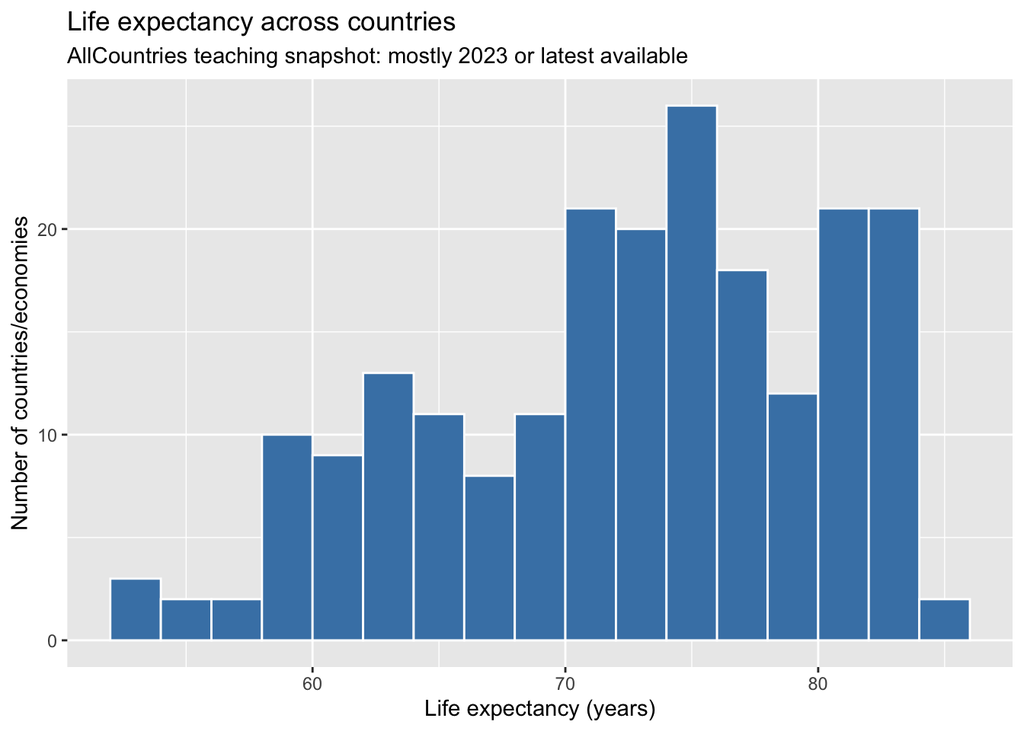

```r
ggplot(filter(country_data, !is.na(life_expectancy)),
       aes(x = life_expectancy)) +
  geom_histogram(binwidth = 2, boundary = 0,
                 fill = "steelblue", color = "white") +
  labs(
    x = "Life expectancy (years)", y = "Number of countries/economies",
    title = "Life expectancy across countries",
    subtitle = "AllCountries teaching snapshot: mostly 2023 or latest available"
  )
```

Consider the following questions:

1. How accurate were your initial guesses about shape, center, and spread? What features surprised you?
2. For **each variable**, compare its mean and median. Which would you use to describe a typical country, and why? Do not compare a dollar gap directly with a gap measured in years.
3. Do you see possible outliers? How might they affect the mean and standard deviation? Would an unusual value necessarily be a recording error?
4. Could a log transformation help display GDP per capita if it is strongly right-skewed? Check that values are positive before using a log. What would become harder to interpret?
5. Would an unweighted mean of country internet-access percentages equal the percentage for all the world’s people? What additional information would a population-weighted calculation require?
6. Which countries are missing a value? Could missing observations, different measurement years, or measurement differences affect our conclusions? What can a single snapshot **not** tell us about change over time?

**Optional group comparison:** Repeat the life-expectancy histogram using `facet_wrap(~ hdi_group)`, excluding missing group labels. Interpret the result cautiously: **life expectancy is itself a component of HDI**, and income is another component. Such group differences are not independent evidence that HDI causes health or economic outcomes.[^5]

**Exit question:** In one or two sentences, explain why the shape of a distribution matters when deciding whether the mean or median better summarizes a social science variable. State whether your conclusion describes countries or individuals.

## Data sources and documentation

## Footnotes

[^1]: Robin Lock, *Lock5Data*, fourth-edition `AllCountries` dataset. The [package reference manual](https://cran.r-project.org/web/packages/Lock5Data/refman/Lock5Data.html) documents 217 observations and 29 variables, mostly 2023 or the most recently available values, with sources accessed in January 2025. Sources include the World Bank, U.S. Energy Information Administration, and United Nations Human Development Report. The [textbook’s fourth-edition data page](https://www.lock5stat.com/datapage4e.html) also provides the data in several formats.
[^2]: [CRAN package page for Lock5Data](https://cran.r-project.org/package=Lock5Data). Version 4.0.1 was published on January 8, 2026. The package publication date is **not** the observation year. This activity uses the fourth-edition `AllCountries`, not `AllCountries1e`, `AllCountries2e`, or `AllCountries3e`.
[^3]: Robin Lock, *Lock5Data*, fourth-edition `AllCountries` dataset. The [package reference manual](https://cran.r-project.org/web/packages/Lock5Data/refman/Lock5Data.html) documents 217 observations and 29 variables, mostly 2023 or the most recently available values, with sources accessed in January 2025. Sources include the World Bank, U.S. Energy Information Administration, and United Nations Human Development Report. The [textbook’s fourth-edition data page](https://www.lock5stat.com/datapage4e.html) also provides the data in several formats.
[^4]: United Nations Development Programme, [Human Development Index](https://hdr.undp.org/data-center/human-development-index). HDI combines life expectancy, schooling, and gross national income per capita. It does not measure every dimension of human development.
[^5]: United Nations Development Programme, [Human Development Index](https://hdr.undp.org/data-center/human-development-index). HDI combines life expectancy, schooling, and gross national income per capita. It does not measure every dimension of human development.